# Relatório 07

Gustavo Cardoso

29/05/2025

# 1 Objetivo

O objetivo deste trabalho é investigar o que fazer quando as pressuposições da ANOVA não são atendidas, com foco na análise de resíduos. Vamos apresentar um exemplo de experimento simulado, no contexto da Engenharia Civil, onde os resíduos não seguem normalidade nem homogeneidade de variância, e aplicar soluções estatísticas para lidar com esse problema.

# 2 Apresentação do relatório

A análise de variância (ANOVA) é uma ferramenta estatística amplamente utilizada para comparar médias de diferentes grupos. No entanto, para que seus resultados sejam válidos, algumas pressuposições precisam ser atendidas:

-Normalidade dos resíduos;

-Homogeneidade das variâncias (homocedasticidade);

-Independência dos resíduos.

Quando essas condições não são satisfeitas, os resultados da ANOVA podem ser comprometidos, levando a conclusões erradas.

# 3 Experimento sobre resistência a compressão do concreto

Um experimento foi conduzido para avaliar a resistência à compressão de blocos de concreto utilizando três diferentes tipos de aditivos. Os dados foram simulados de forma que a variância entre os grupos seja propositalmente desigual, violando uma das pressuposições da ANOVA.

```r
# Simulação dos dados
set.seed(42)

# Três tratamentos com diferentes variâncias
aditivo <- rep(c("Aditivo1", "Aditivo2", "Aditivo3"), each = 10)
resistencia <- c(
  rnorm(10, mean = 28, sd = 1),
  rnorm(10, mean = 32, sd = 5),  # Maior variabilidade
  rnorm(10, mean = 30, sd = 2)
)

dados <- data.frame(aditivo, resistencia)
```

# 4 ANOVA e Diagnóstico de Resíduos

Ajuste do Modelo:

```r
modelo <- aov(resistencia ~ aditivo, data = dados)
summary(modelo)
```

```
##             Df Sum Sq Mean Sq F value Pr(>F)
## aditivo      2   35.1   17.53   0.725  0.493
## Residuals   27  652.6   24.17
```

Após o ajuste do modelo, é essencial avaliar os resíduos para verificar se atendem às pressuposições.

Aplicando a Análise dos Resíduos:

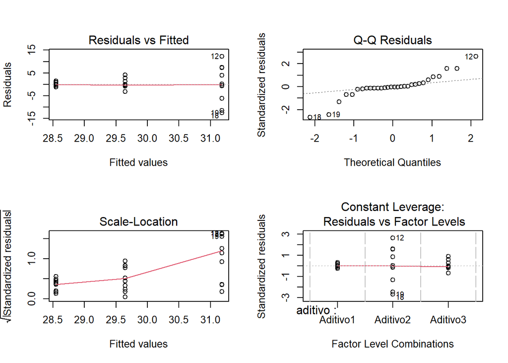

```r
par(mfrow = c(2, 2))
plot(modelo)
```

# 5 Teste de Normalidade de Shapiro-Wilk:

Verifica se os resíduos seguem distribuição normal.

```r
shapiro.test(residuals(modelo))
```

```
##
##  Shapiro-Wilk normality test
##
## data:  residuals(modelo)
## W = 0.87432, p-value = 0.002094
```

Se o valor-p for menor que 0,05, rejeita-se a normalidade.

# 6 Teste de homogeneidade de variância (Bartlett ou Levene):

Pressupõe normalidade. Indicado quando os dados são aproximadamente normais.

```r
bartlett.test(resistencia ~ aditivo, data = dados)
```

```
##
##  Bartlett test of homogeneity of variances
##
## data:  resistencia by aditivo
## Bartlett's K-squared = 34.666, df = 2, p-value = 2.967e-08
```